# FARMR!SK automatic report

Farm: bc6_v2

Published

Last Updated on Tuesday 2 December, 2025 (13:11:37)

**User ID:** trucha **Farm ID:** bc6_v2 **Survey date:** 2025-03-10

# **Risk analysis results**

> *All risk values from Monte Carlo simulations are provided as median (50th percentile) with 95% confidence interval (97.5%–2.5%).*

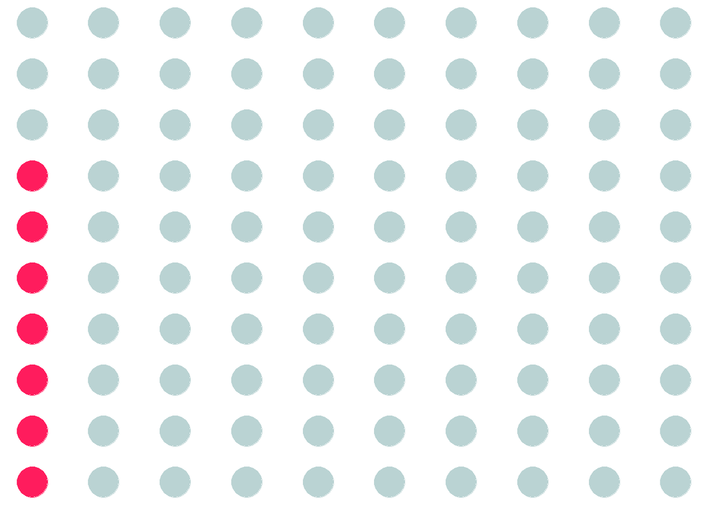

(a) IBR

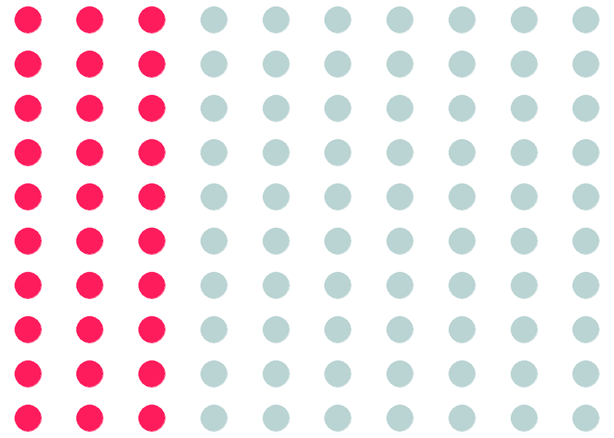

(b) BVD

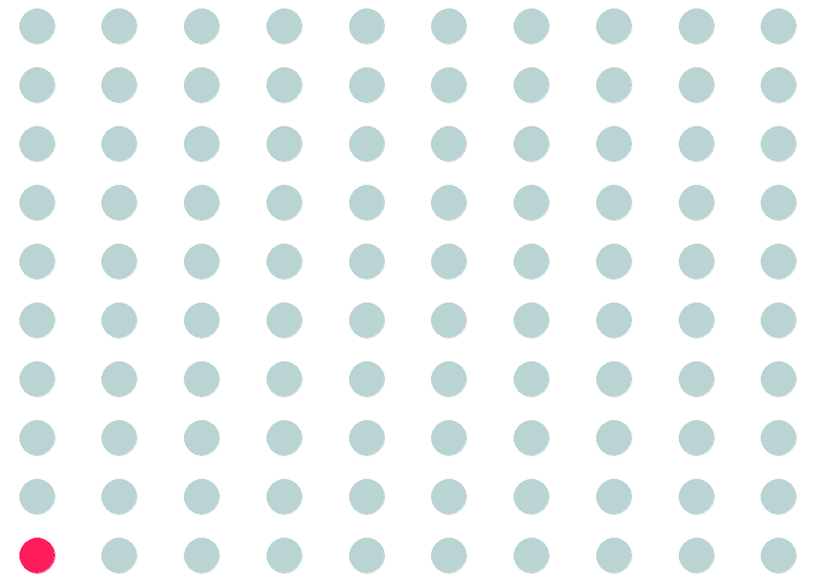

(c) TB

Figure 1.1: Risk of disease entry

The main pathways of disease entry are: **Animals from other origin** and **Neigbouring farms**.

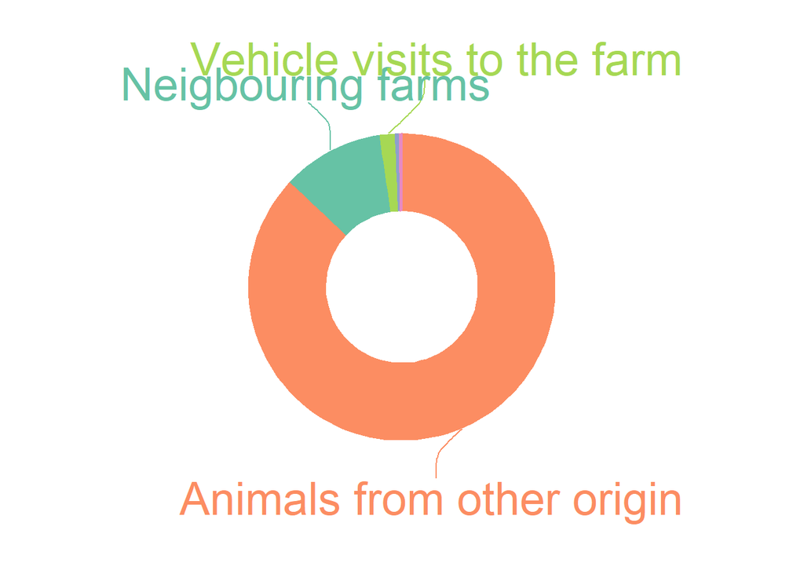

(a) IBR

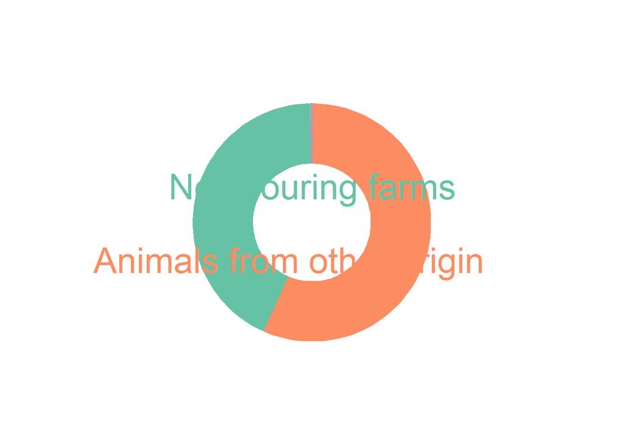

(b) BVD

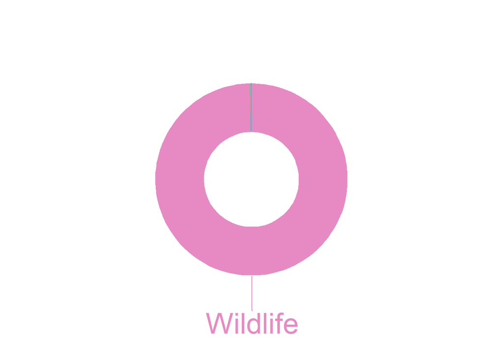

(c) TB

Figure 1.2: Risk of disease entry by pathway

## **Infectious Bovine Rhinotracheitis (IBR)**

### Current risk

Annual risk of IBR entry in the farm: **7%** (6.39-7.58%)

By pathway:

- Animals from other origin: **6.15%** (5.56-6.7%)
- Neigbouring farms: **0.755%** (0.559-0.98%)
- Vehicle visits to the farm: **0.113%** (0.033-0.248%)
- Animal transport: **0.0299%** (0.0111-0.048%)
- People visits to the farm: **0.018%** (0.00589-0.0333%)

### Risk reduction of biosecurity measures

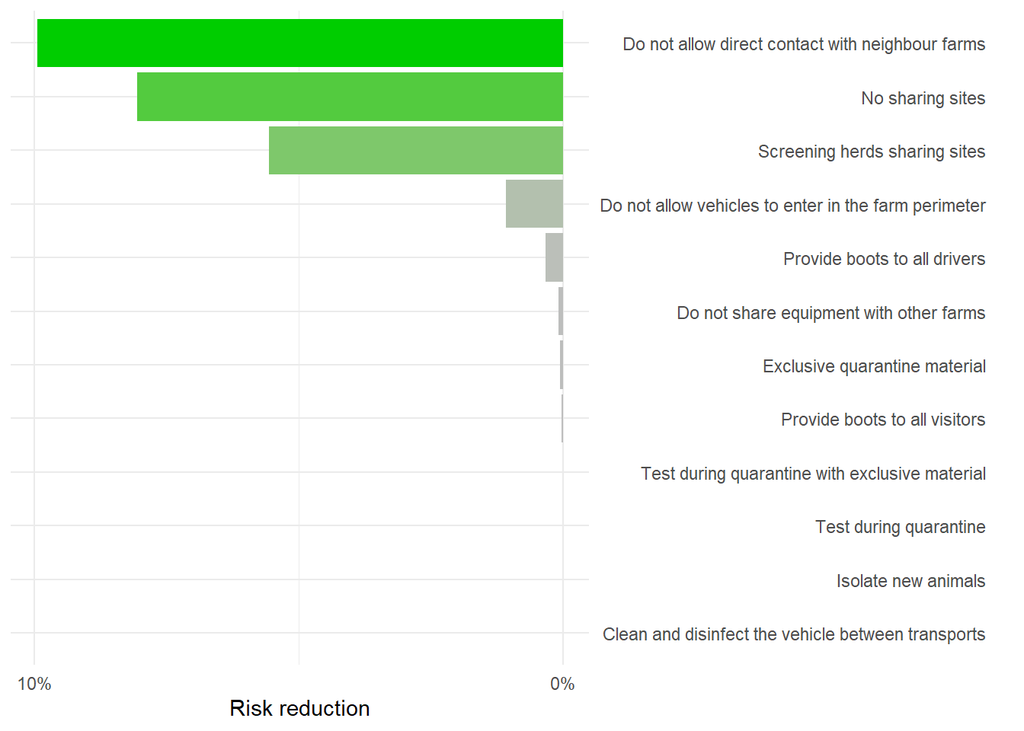

## **Bovine viral diarrhea (BVD)**

### Current risk

Annual risk of BVD entry in the farm: **29.3%** (23.4-34.7%)

By pathway:

- Animals from other origin: **18.1%** (11.7-23.9%)
- Neigbouring farms: **13.7%** (10.5-16.3%)
- People visits to the farm: **0.0302%** (0.00835-0.0683%)
- Vehicle visits to the farm: **0.0241%** (0.00724-0.0577%)
- Animal transport: **4.93e-06%** (3.26e-07-4.94e-05%)

### Risk reduction of biosecurity measures

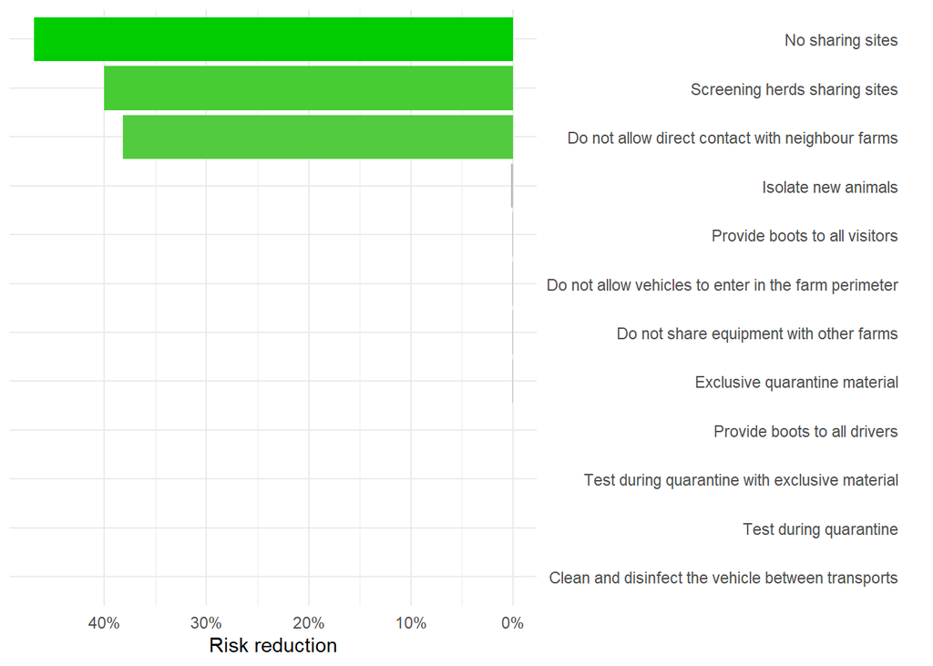

## **Bovine Tuberculosis (TB)**

### Current risk

By pathway:

- Wildlife: **1.48%** (0.652-2.98%)
- Neigbouring farms: **0.00188%** (0.00121-0.00276%)
- Animals from other origin: **0.00136%** (0.000982-0.00185%)
- Vehicle visits to the farm: **6.04e-05%** (3.3e-06-0.000415%)
- People visits to the farm: **1.47e-05%** (7.27e-07-6.59e-05%)
- Animal transport: **8.64e-06%** (6.47e-07-3.09e-05%)

### Risk reduction of biosecurity measures

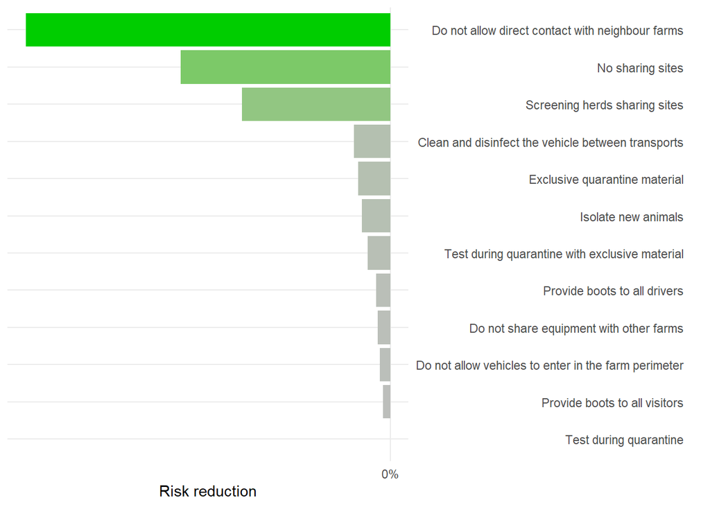

# 🐄 Description of the farm

## Farm information

**Location:** Cataluña, Spain

**Farm type:** Beef cattle, NA

**Cattle cens:**

- 163 Calves ( <8 m)
- 60 Heifers (8 - 24 m)
- 140 Adult cows (>24 m)
- 6 Bulls

**Other animals in the farm:**

- **Direct contact with cattle:** 2 dogs, 2 horses, 4 cats
- **No direct contact with cattle:** 200 pigs, 200 poultry

**Neighbours**: 1 cattle farms within a 1-2km radious, possible direct contact (IBR: 0.755%, BVD: 13.7%, TB: 0.00188%)

## Farm vehicles

| veh_id | Size | Shared | Cleaning |
| --- | --- | --- | --- |
| amarillo (a) | 20m2 | No | From time to time |
| gris (b) | 9m2 | No | From time to time |

## Visits

### People entering the barn

| Visit | Type | Frequency | Boots | Equipment | Risk |
| --- | --- | --- | --- | --- | --- |
| veterinario | External veterinarians | 6 | Always used in other farms, sometimes cleaned and disinfected | Always used in other farms, sometimes cleaned and disinfected | IBR: 0.018%, BVD: 0.0302%, TB: 1.47e-05% |
| plagas | Other professionals (e.g. electrician, plumber…) | 12 | Never used in other farms | Never used in other farms | negligible risk |

### Vehicles entering the farm perimeter

| Visit | Type | Frequency | Driver | Risk |
| --- | --- | --- | --- | --- |
| matadero vacas | Slaughterhouse vehicle | 1 | Enters areas used by farm animals (no contact with animals), boots always used in other farms, never cleaned and disinfected | IBR: 0.0542%, BVD: 0.0116%, TB: 3.37e-05% |
| matadero terneros | Slaughterhouse vehicle | 14 | No contact with animals | IBR: 0.0305%, BVD: 0.00599%, TB: 1.94e-06% |
| comida | Feed vehicle | 50 | - | IBR: 0.0118%, BVD: 0.00238%, TB: 7.26e-07% |
| cadaveres | Rendering vehicle | 6 | - | IBR: 0.00185%, BVD: 0.000404%, TB: 1.05e-07% |

# 🚚 Movements

Animal movements in the last 12 months

| mov_id | When | Origin | Animals moved | Shared site | Vehicle used | Risk |
| --- | --- | --- | --- | --- | --- | --- |
| macho_ficticio | ➡️ One-off entry: 2025-11-12 | Other farm/s: Lleida | 1 Bulls | - | Own amarillo | IBR: 2.78%, BVD: 0.688%, TB: 4.33e-05% |
| angus | ➡️ Recurrent entry: 1 times/year | Other farm/s: Barcelona | 1 Bulls | - | Own gris | IBR: 2.77%, BVD: 0.687%, TB: 2.14e-05% |
| pasto_llesui | 🔁 Recurrent round: 1 times/year, out for 180 days | Pasture: Lleida | 58 Calves ( <8 m), 70 Adult cows (>24 m) | Shared with 100 animals from 2 farms (presence of bulls) | Own gris | IBR: 0.435%, BVD: 11.8%, TB: 0.33% |
| concurso_nacional_bruna | 🔁 Recurrent round: 1 times/year, out for 1 days | Livestock fair: Cataluña | 1 Calves ( <8 m), 1 Adult cows (>24 m) | Shared with 80 animals from 10 farms NA | Own amarillo | IBR: 0.179%, BVD: 5.15%, TB: 0.000213% |
| macho_bruna | ➡️ Recurrent entry: 0.5 times/year | Genetic selection centre: Cataluña | 2 Bulls | - | External | IBR: 0.12%, BVD: 0.677%, TB: 3.11e-05% |
| fira_berga | 🔁 Recurrent round: 1 times/year, out for 3 days | Livestock fair: Cataluña | 3 Heifers (8 - 24 m) | Shared with 30 animals from 10 farms NA | Own gris | IBR: 0.00169%, BVD: 0.0355%, TB: 4.13e-06% |
| pasto_elcanto | 🔁 Recurrent round: 1 times/year, out for 180 days | Pasture: Lleida | 60 Heifers (8 - 24 m) | Shared with 10 animals from 3 farms | Own amarillo | IBR: 0.000565%, BVD: 0.0117%, TB: 0.11% |
| pasto_sant_jaume | 🔁 Recurrent round: 1 times/year, out for 118 days | Pasture: Barcelona | 55 Calves ( <8 m), 70 Adult cows (>24 m) | No | Own amarillo | IBR: 0%, BVD: 0%, TB: 0.304% |

### Health status and tests in origin

[output not shown]

### Quarantine

#### Characteristics

*No quarantine*

# 🐗 Wildlife

**Wildlife:** IBR: -, BVD: -, TB: 1.48%

- Outdoors grazing: Outdoors grazing, no complete perimeter fence (electric) (IBR: -, BVD: -, TB: 0.446%)
- Pasture (trashumance): No pastures

### Farm water points

| Risk point | Mud/Organic | Risk |
| --- | --- | --- |
| 100% High waterer (>90cm) | 0% | 0.0% (0.0-0.0%) |
| 100% Waterhole | 100% | 0.2% (0.024-0.8%) |
| 100% River | 100% | 0.0019% (0.00018-0.0088%) |
| 100% feed | 100% | 0.2% (0.027-0.78%) |

### Pasture water points

*No pasture water points*

# Comments

- h (pasture_1)
- solorecria (pasture_3)
- macho_bruna: no va solo pero vienen del mismo sitio (complete)

# Technical Annex